# Updated Report: Association Analysis of the Self-Compassion and Gratitude Scales

Cheng Peng

10/21/2026

# Introduction

The goal of this research project is to measure the level of self-compassion as well as the self-care of BSW and MSW students in a Social Work Program at a regional University. We will be using the following two reliable and validated instruments to measure their level of self-compassion and self-care as they immerse themselves in the helping profession. We hope to see how the SC of the students correlates to other independent variables i.e. undergrad/grad program social work, age, education level, religiosity, spirituality, gender, etc.

1. The Self-Compassion Scale
2. The Gratitude Questionnaire

The purpose of our research is to study the perception of self-compassion in social work students and how it can link to self-care as well as success in the social work program and field. This will help provide students with self-care practices during their training to thrive in the profession in the future.

# Data Management and Analyzing Survey Instruments

The original survey data have three components, self-compassion scale and gratitude questionnaire instruments, and some demographic questions.

The three components have different portions of missing values. We split the original data set into three subsets of data and impute the missing values related to the self-compassion and gratitude data based on the survey instruments. Since there are only a few missing values, we replace the missing values in each survey question with the mode of the associated survey item. We create indexes of the two instruments separately to aggregate the information in the two survey data sets.

We will perform both principal component analysis (PCA) and exploratory factor analysis (EFA).

## Handling Missing Values Self-Compassion Instrument

This instrument contains only the data associated with the 12 items in the survey instrument. In the original data file, the 12 variables are named as Q2_1, Q2_2, …, Q2_12. We impute the missing value by replacing the missing value in each of the 12 items with the mode of the corresponding survey items. Since there are only a few missing values in this instrument, this imputation will not impact the subsequent PCA and EFA.

## Handling Missing Values in Gratitude Scale

The gratitude questionnaire contains only the variables associated with gratitude questions. The variables used in the original data file are Q3_1, Q3_2, …, Q3_6. We use the same mode imputation method to fill in the missing values as used in the above self-compassion survey data. The gratitude questionnaire has even fewer missing values. Any imputation will not impact any subsequent analysis.

Since Likert scales of the Q3_3 and Q3_6 were in reverse order in the design. We transform back the usual order and create a new dataset using the same variable names.

## Handling Demographic Variables

A few missing values occurred in the years of education and employment that are imputed using the auxiliary information in the variables of age, the years of education, and the length of employment.

The major issue of these categorical variables is the imbalance category. The following modifications to the original demographic variables are utilized.

```
# replace missing values with 99.
demographic00[is.na(demographic00)] <- 99
# Create a frequency table for collapsing categories
list(Q8.1=table(demographic00$Q8_1),
     Q8.2=table(demographic00$Q8_2),
     Q8.3=table(demographic00$Q8_3),
     Q8.5=table(demographic00$Q8_5),
     Q8.6=table(demographic00$Q8_6),
     Q.9=table(demographic00$Q9),
     Q.11=table(demographic00$Q11),
     Q.13=table(demographic00$Q13),
     Q.14=table(demographic00$Q14),
     Q.15=table(demographic00$Q15),
     Q.16=table(demographic00$Q16),
     Q.17=table(demographic00$Q17),
     Q.18=table(demographic00$Q18),
     Q.19=table(demographic00$Q19),
     Q.20=table(demographic00$Q20)
     )
```

```
grp.age = Q8_1:  1 = (3,23], 2 = [24, 30],  3 = [31, 59]
grp.edu = Q8_2:    1 = [0,15] associate, 2 = [15.5,18.5] bachelor, 3 = [19, 25]  advdegree
grp.empl = Q8_3:   1 = [0,5]  entry, 2 = [5.5,10] junior, 3 = [10.5, 35]   senior
kid.num = Q8_5: 1 = (0) No child, 2 = at least one child
home.size = Q8_6:  1 = (1), 2 = (2), 3 = 3 or more

gender = Q9:  1 = (2) female, 2 = (1,3,5,7) male
race = Q11:   1 = (1)   white,   2 = (2,3) other
marital.st = Q13: 1 = (1) single, 2 = (2) married/civil Partner, 3 = other
disability = Q14:  1 = yes,  2 = No
religion = Q15:  1 = 9 (no religion), 2 = (1,2,3,6,7,8,10,11,99) (religion)
Sexual.orient = Q16:  1 = (4)  heterosexual,  2 = (1,2,3,5,6,7,10) other
poli.affil = Q17: 1 = (4)ind, 2 = (5,6,7)  democrats, 3 = (1,2,3, 99) other
SW.Program = Q18: 1 = (1) Business Student, 2 = (2,99) SWK Students
Urbanity = Q19:  1 = (1) urban, 2 = (2) rural, 3 = (3) suburban
Spirituality = Q20: 1 = (1,2,3) low, 2 = (4)   moderate,  3 = (5,6,7) high
```

We re-code the demographic variables based on the above modification. The modified demographic variables will be used in subsequent modeling.

# PCA and EFA for Survey Instruments

Different methods for finding the number of components/factors to retain in an exploratory principal component or factor analysis are used in this analysis. The classical ones are the Kaiser rule, the parallel analysis, and the usual scree test. Non-graphical solutions by Raiche et al. (2013) to the Cattell subjective scree test are also proposed: an acceleration factor (AF) and the index of the optimal coordinate OC. The acceleration factor indicates the turning point of the scree plot. It corresponds to the acceleration of the curve, i.e. the second derivative. The optimal coordinates are the extrapolated coordinates of the previous eigenvalue that allow the observed eigenvalue to go beyond this extrapolation.

Our objective is to aggregate the information to a few principle components that carry as much information as possible, then use simple statistical analysis to characterize the behavior of the resulting PCA or EFA scores and relevant association analyses. Therefore, the standard orthogonal rotation is used to avoid the potential correlation between the resulting PCA or EFA scores.

Whether PCA or EFA will be used and how many of the PCAs or EFAs will be selected will be based on the well-received analytical methods and subjective judgment on the proportion of variables explained by the selected PCAs or EFAs. In case, both PCA and EFA give similar results in terms of the proportion of the total variation, we will go with PCA since PCA’s estimation of loading does not assume distribution of normality to define the maximum likelihood objection. This will reduce the risk of model misspecification.

## Some R Functions For Extracting Information from PCA and EFA

We defined and modified some R functions to extract specific information from the PCA or EFA analyses to address the analytic questions outlined in the previous section.

**My.plotnScree** produce a plot that summarized the results of four commonly used methods used for identifying the number of components or factors to be retained for exploratory analyses. This graphics function was modified from the *plotnScree()* from library **nFactors**.

**My.loadings.var** produce a list of two objects: factor loadings and proportion variance explained by each factor. There are no existing R functions that can be used to extract the proportion of variance from the output of *factanal()*. The function can also extract similar information from the output of a PCA but we need to specify the method in the argument.

## Self-compassion Index

We start with some correlation plot to see the relevance of the PCA procedure on the self-compassion data.

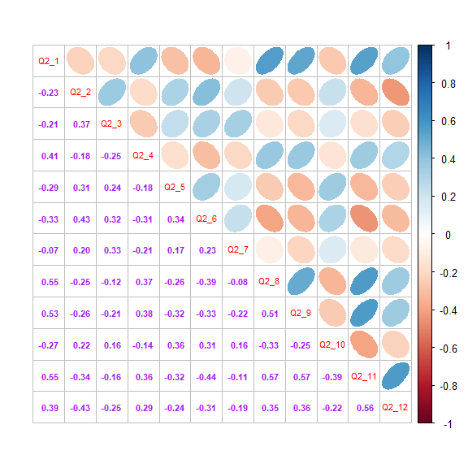

The pairwise correlation plot reveals the potential relevance of PCA. The shape of an ellipse represents the correlation. The skinnier the ellipse, the higher the correlation. The direction reflects whether a correlation is positive or negative. The off-diagonal direction implies s positive correlation while the main diagonal direction implies a negative association.

Figure 1 shows the moderate association between individual survey items. This implies that the PCA is relevant in aggregating the information in the survey items.

Similar to López et. al. (2018), we use the six positive items associated with mindfulness, self-kindness and the sense of common humanity to define the self-compassion index.

From the pair-wise correlation plot we can see that some of the items are reversely scored. We next change back the scale so that all items are positively correlated.

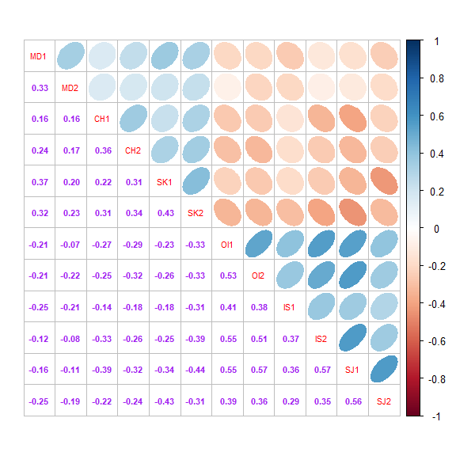

The pairwise correlation plot reveals the potential relevance of PCA. Group items based on self-compassion and self-coldness

Next, we make the following heatmap to illustrate the pairwise correlation between the items in the survey instrument based on the positive adjustment of the scale.

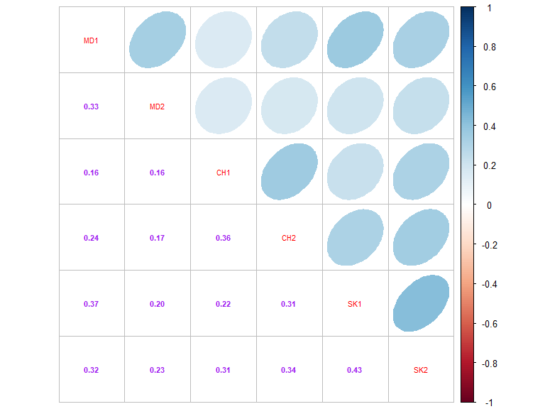

### Intern Consistency

With the adjusted the scores in the self-compassion instrument, we calculate the one of the commonly used internal consistency reliability Cronbach alpha as follows.

Next we find the Cronbach alpha and it 95% confidence interval.

Confodence Interval of Cranbach Alpha

| LCI | alpha | UCI |
| --- | --- | --- |
| 0.6331 | 0.7002 | 0.7587 |

### PCA Extraction and Number of PCA Determination

The number of PCAs selected for the future exploratory analyses is the key issue and is also the first question we need to address before we move to any further analysis with the PCA scores. Raiche et al (2013) simulation-based test and Scree plot indicate that it is sufficient to choose the first principle component for future analysis. For exploratory purposes, we will choose the first two principal components for both PCA and EFA procedures and use them for association analysis.

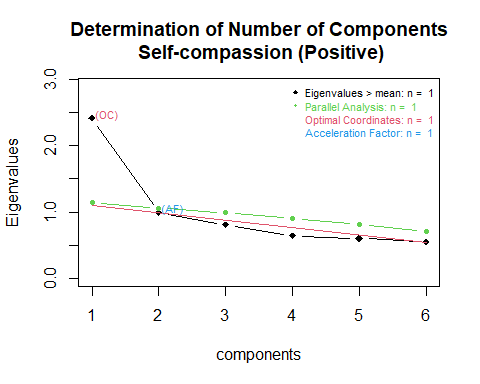

Different methods of identification of the number of principal components to be retained in exploratory analysis: Kaiser’s eigenvalue rule, Raiche et al Monte Carlo simulation method (parallel analysis), optimal coordinate (OC) index, and accelerate factor (AF) method.

Figure 2 indicates that it is sufficient to retain the first principle component for the subsequent analysis. In the following, we will extract the first two PCAs. The PCA factor loadings and the proportion of variance explained by the retained PCAs are summarized in the following tables.

Factor loadings of the first few PCAs and the cumulative proportion of variation explained by the corresponding PCAs in the self-compassion survey.

|  | PC1 | PC2 |
| --- | --- | --- |
| **MD1** | 0.414 | 0.47 |
| **MD2** | 0.329 | 0.556 |
| **CH1** | 0.363 | -0.546 |
| **CH2** | 0.415 | -0.397 |
| **SK1** | 0.447 | 0.066 |
| **SK2** | 0.466 | -0.096 |

Cumulative and proportion of variances explained by each principal component in the self-compassion survey.

|  | PC1 | PC2 |
| --- | --- | --- |
| **Standard deviation** | 1.553 | 0.996 |
| **Proportion of Variance** | 0.402 | 0.165 |
| **Cumulative Proportion** | 0.402 | 0.567 |

Next we extract the self-compassion index in the following code

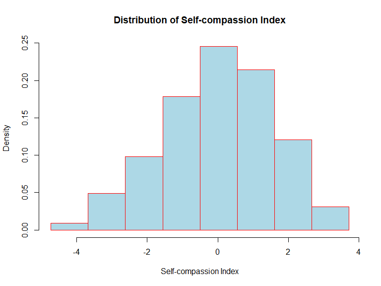

Histogram of the first principle component extract from the self-compassion survey.

## Gratitude Questionaire

In this section, we perform the same analysis on the gratitude survey instrument. First of all, we present a pairwise correlation plot to display the correlation between individual survey items in the gratitude survey instrument.

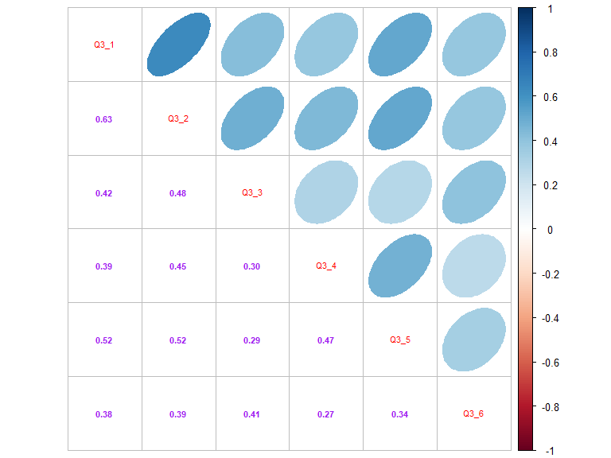

The pairwise correlation plot reveals the potential relevance of PCA for the gratitude instrument. The shape of an ellipse represents the correlation. The skinnier the ellipse, the higher the correlation. The direction reflects whether a correlation is positive or negative. The off-diagonal direction implies s positive correlation while the main diagonal direction implies a negative association.

Figure 3 shows that a moderate correlation exists between individual variables. This implies the PCA and EFA can be used to aggregate the information in the set original survey items. Next, we estimate the number of PCAs or EFAs to be retained for the subsequent analysis using the commonly used procedures and summarize the results in the following figure 4.

### Cronbach’s Alpha

The internal consistency measure, Cronbach’s alpha, of the gratitude instruments calculated below

Confodence Interval of Cranbach Alpha

| LCI | alpha | UCI |
| --- | --- | --- |
| 0.7389 | 0.7867 | 0.8283 |

### PCA Extraction and Number of PAC Determination

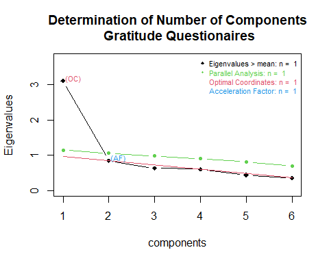

Different methods of identification of number of principle components to be retained in exploratory analysis for the gratitude survey instrument: Kaiser’s eigenvalue rule, Raiche et al Monte Carlo simulation method (parallel analysis), optimal coordinate (OC) index, and accelerate factor (AF) method.

Factor loadings of the first few PCAs and the cumulative proportion of variation explained by the corresponding PCAs in the Gratitude Questionaire Survey.

|  | PC1 | PC2 |
| --- | --- | --- |
| **Q3_1** | 0.45 | 0.044 |
| **Q3_2** | 0.467 | 0.035 |
| **Q3_3** | 0.375 | -0.538 |
| **Q3_4** | 0.374 | 0.489 |
| **Q3_5** | 0.416 | 0.418 |
| **Q3_6** | 0.354 | -0.542 |

Cumulative and proportion of variances explained by each principle component from the Gratitude Questionaire Survey. A similar analysis was also conducted using EFA. The result indicates that the first principle factors is sufficient for exploratory analysis. The proportion of the total variation explained by the first factor is about 40% which is about 10% less than that in the first principle component. We will use the first PCA and call it as gratitude index.

|  | PC1 | PC2 | PC3 | PC4 | PC5 | PC6 |
| --- | --- | --- | --- | --- | --- | --- |
| **Standard deviation** | 1.763 | 0.92 | 0.797 | 0.781 | 0.665 | 0.599 |
| **Proportion of Variance** | 0.518 | 0.141 | 0.106 | 0.102 | 0.074 | 0.06 |
| **Cumulative Proportion** | 0.518 | 0.659 | 0.765 | 0.866 | 0.94 | 1 |

Next we extract the first PCA scores.

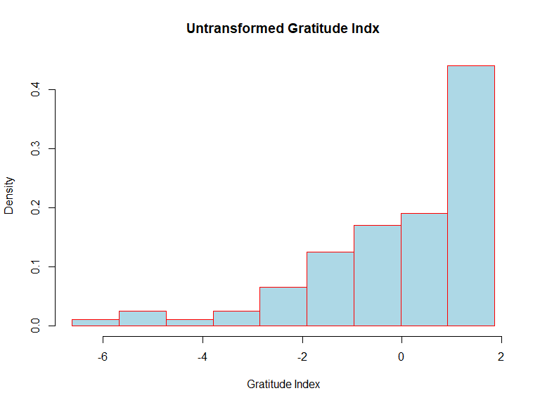

To define a meaningful index of self-compassion, we want to make sure that the proposed index is positively correlated to the individual item. Since the principle component analysis algorithm is essentially a orthogonal rotation (transformation), we can adjust the direction of the coordinate system to make the PCA scores meaningful index for subsequent association analysis. The is the plot of the pairwised association between the individual items and the two new PCA scores.

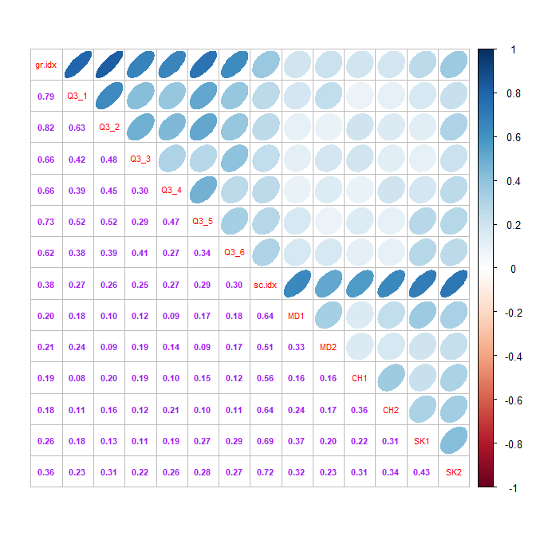

Pair-wise correlation plot between individual survey items and the two first PCA scores extract from the two instruments.

## Final Analytic Data Set

We now create a dataframe that contains PCAs based on self-compassion and gratitude indexes and the demographics.

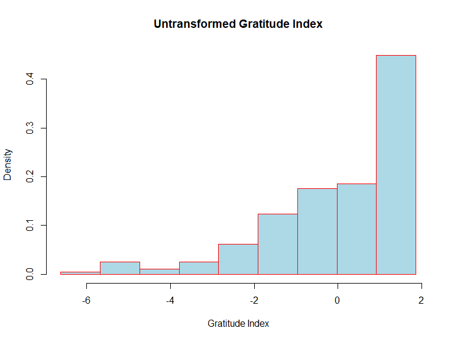

In next section, we focus on building regression models to address the research questions.

# Association Aanalyses

Three families of linear regression models will be built in this section. The final models in each of the three families will be presented to address the association between self-compassion and other variables of interests.

## Best Subset Selection

In this section, we build and search the best regression model to detect the potential association between the self-compassion index and the demographics. we use an automatic variable selection procedure to find the final model that contains significant variables. The subset selection methods allows us to select top predictors.

```
## [1] 6
```

```
##      (Intercept)      home.size3+ urbanitysuburban  spiritualitylow
##        0.2847187        0.4522247       -0.5437709       -0.5437250
##           gr.idx
##        0.2659892
```

```
##
## Call:
## lm(formula = sc.idx ~ home.size + urbanity + spirituality + gr.idx,
##     data = final.data.step)
##
## Residuals:
##     Min      1Q  Median      3Q     Max
## -4.8152 -0.7530  0.1739  0.9622  2.7134
##
## Coefficients:
##                  Estimate Std. Error t value Pr(>|t|)
## (Intercept)       0.28243    0.26764   1.055   0.2927
## home.size3+       0.45262    0.21003   2.155   0.0324 *
## urbanitysuburban -0.54151    0.26451  -2.047   0.0420 *
## urbanityurban     0.00430    0.31398   0.014   0.9891
## spiritualitylow  -0.54431    0.22157  -2.457   0.0149 *
## gr.idx            0.26599    0.06343   4.193 4.25e-05 ***
## ---
## Signif. codes:  0 '***' 0.001 '**' 0.01 '*' 0.05 '.' 0.1 ' ' 1
##
## Residual standard error: 1.414 on 186 degrees of freedom
## Multiple R-squared:  0.1933, Adjusted R-squared:  0.1716
## F-statistic: 8.912 on 5 and 186 DF,  p-value: 1.322e-07
```

### Best SubSet Selection

We use the following best subset selection to select top 10 strong variables to include in the final model.

```
## [1] 6
```

[output not shown]

|  | Estimate | Std. Error | t value | Pr(>\|t\|) |
| --- | --- | --- | --- | --- |
| **(Intercept)** | 0.393 | 0.3789 | 1.037 | 0.3011 |
| **grp.age[24,30]** | -0.2536 | 0.2853 | -0.8888 | 0.3753 |
| **grp.age[30,99]** | -0.01636 | 0.3496 | -0.04679 | 0.9627 |
| **grp.empljunior** | -0.2016 | 0.2915 | -0.6917 | 0.49 |
| **grp.emplsenior** | -0.3352 | 0.361 | -0.9285 | 0.3544 |
| **home.size3+** | 0.3686 | 0.2293 | 1.608 | 0.1097 |
| **gendermale** | 0.336 | 0.2757 | 1.219 | 0.2247 |
| **disabilityyes** | -0.4895 | 0.2778 | -1.762 | 0.07979 |
| **poli.affilModDemocrats** | -0.1774 | 0.2887 | -0.6145 | 0.5397 |
| **poli.affilRepublican** | -0.2025 | 0.2884 | -0.702 | 0.4836 |
| **poli.affilStrongDemocrats** | 0.3329 | 0.3187 | 1.045 | 0.2976 |
| **programSW** | 0.2193 | 0.2555 | 0.8584 | 0.3918 |
| **urbanitysuburban** | -0.4564 | 0.2792 | -1.635 | 0.1039 |
| **urbanityurban** | -0.01536 | 0.3398 | -0.04521 | 0.964 |
| **spiritualitylow** | -0.5502 | 0.2294 | -2.398 | 0.01753 |
| **gr.idx** | 0.2777 | 0.06816 | 4.075 | 6.966e-05 |

```
##
## Call:
## lm(formula = sc.idx ~ grp.age + grp.empl + home.size + gender +
##     disability + poli.affil + program + urbanity + spirituality +
##     gr.idx, data = final.data.step)
##
## Residuals:
##     Min      1Q  Median      3Q     Max
## -4.4351 -0.8490  0.1329  0.9676  2.5276
##
## Coefficients:
##                           Estimate Std. Error t value Pr(>|t|)
## (Intercept)                0.39297    0.37890   1.037   0.3011
## grp.age[24,30]            -0.25361    0.28533  -0.889   0.3753
## grp.age[30,99]            -0.01636    0.34961  -0.047   0.9627
## grp.empljunior            -0.20165    0.29153  -0.692   0.4900
## grp.emplsenior            -0.33517    0.36099  -0.928   0.3544
## home.size3+                0.36856    0.22926   1.608   0.1097
## gendermale                 0.33598    0.27573   1.219   0.2247
## disabilityyes             -0.48950    0.27779  -1.762   0.0798 .
## poli.affilModDemocrats    -0.17740    0.28869  -0.615   0.5397
## poli.affilRepublican      -0.20246    0.28840  -0.702   0.4836
## poli.affilStrongDemocrats  0.33295    0.31870   1.045   0.2976
## programSW                  0.21928    0.25546   0.858   0.3918
## urbanitysuburban          -0.45640    0.27917  -1.635   0.1039
## urbanityurban             -0.01536    0.33975  -0.045   0.9640
## spiritualitylow           -0.55015    0.22941  -2.398   0.0175 *
## gr.idx                     0.27774    0.06816   4.075 6.97e-05 ***
## ---
## Signif. codes:  0 '***' 0.001 '**' 0.01 '*' 0.05 '.' 0.1 ' ' 1
##
## Residual standard error: 1.417 on 176 degrees of freedom
## Multiple R-squared:  0.2335, Adjusted R-squared:  0.1681
## F-statistic: 3.574 on 15 and 176 DF,  p-value: 2.134e-05
```

[output not shown]

**Group means**

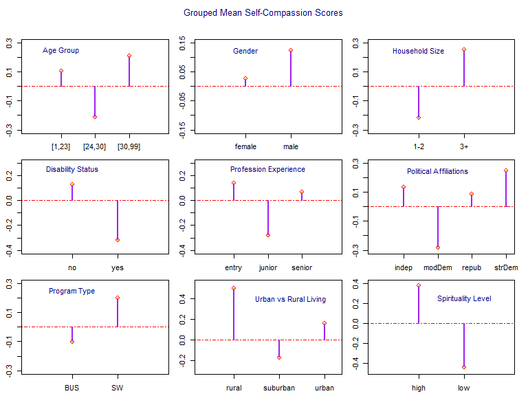

### Gratitude Index versus Demographic Adjusted by Self-compassion Index

The linear regression model will be based on the index scores created based on the principle component analysis.

```
## [1] 6
```

```
##               (Intercept)            grp.age[24,30]           kid.numWith-kid
##                 1.0940333                 0.3208304                -0.3272531
##                gendermale           marital.stother          religionreligion
##                -0.8516187                 0.4248014                -0.6353602
##        sexual.orientother    poli.affilModDemocrats poli.affilStrongDemocrats
##                -0.3382331                -0.6713880                -0.4689883
##                 programSW           spiritualitylow                    sc.idx
##                 0.4229411                -0.6363173                 0.3039110
```

|  | Estimate | Std. Error | t value | Pr(>\|t\|) |
| --- | --- | --- | --- | --- |
| **(Intercept)** | 0.8958 | 0.5941 | 1.508 | 0.1334 |
| **grp.age[24,30]** | 0.4562 | 0.2919 | 1.563 | 0.1199 |
| **grp.age[30,99]** | 0.3572 | 0.3571 | 1 | 0.3186 |
| **kid.numWith-kid** | -0.4156 | 0.2876 | -1.445 | 0.1503 |
| **gendermale** | -0.9316 | 0.282 | -3.303 | 0.001156 |
| **marital.stother** | 0.355 | 0.3679 | 0.9648 | 0.3359 |
| **marital.stsingle** | -0.04939 | 0.351 | -0.1407 | 0.8883 |
| **religionreligion** | -0.6185 | 0.4137 | -1.495 | 0.1367 |
| **sexual.orientother** | -0.2928 | 0.2912 | -1.005 | 0.316 |
| **poli.affilModDemocrats** | -0.516 | 0.2923 | -1.765 | 0.07924 |
| **poli.affilRepublican** | 0.2966 | 0.3022 | 0.9814 | 0.3277 |
| **poli.affilStrongDemocrats** | -0.4024 | 0.3333 | -1.207 | 0.2289 |
| **programSW** | 0.3588 | 0.2572 | 1.395 | 0.1647 |
| **spiritualitylow** | -0.5847 | 0.2457 | -2.38 | 0.01838 |
| **sc.idx** | 0.3385 | 0.07274 | 4.653 | 6.337e-06 |

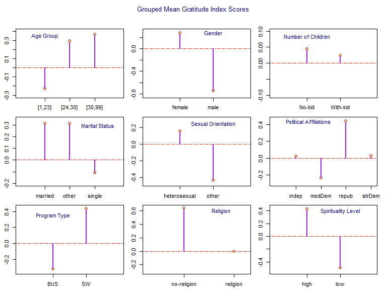

[output not shown]

### Relationship between Self-compassion and Gratitude

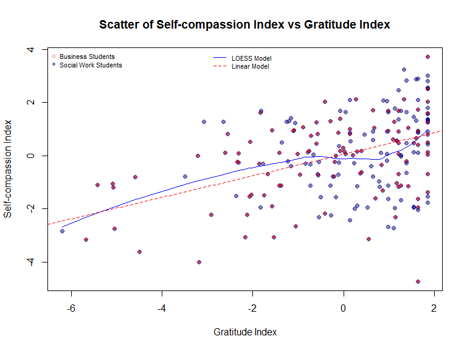

The marginal association between self-compassion and gratitude index

|  | Estimate | Std. Error | t value | Pr(>\|t\|) |
| --- | --- | --- | --- | --- |
| **(Intercept)** | -0.1468 | 0.1558 | -0.9426 | 0.347 |
| **poly(gr.idx, 3, raw = TRUE)1** | 0.2406 | 0.0889 | 2.707 | 0.0074 |
| **poly(gr.idx, 3, raw = TRUE)2** | 0.0927 | 0.0639 | 1.451 | 0.1483 |
| **poly(gr.idx, 3, raw = TRUE)3** | 0.0218 | 0.0127 | 1.708 | 0.0891 |

Note. ANCOVA adjusted for age, gender, disability, spirituality, neighborhood, and household (home size). Adjusted mean difference = SW minus non-SW program; positive values favor SW students. Partial η² and Cohen’s d computed from Type II SS model.

|  | Adjusted_Mean_Difference | CI_95 | F | p | Partial_eta2 | Cohens_d |
| --- | --- | --- | --- | --- | --- | --- |
| Self-compassion | 0.40 | [-0.08, 0.88] | 2.75 | 0.099 | 0.014 | 0.28 |
| Gratitude | 0.41 | [-0.11, 0.92] | 2.41 | 0.122 | 0.012 | 0.26 |

# References

Raiche, G., Walls, T. A., Magis, D., Riopel, M. and Blais, J.-G. (2013). Non-graphical solutions for Cattell’s scree test. *Methodology*, 9(1), 23-29.

Golino, H. F., & Epskamp, S. (2017). Exploratory graph analysis: A new approach for estimating the number of dimensions in psychological research. *PloS One*, 12(6), e0174035.

Franklin, Scott B., Gibson, David J., Robertson, Philip A., Pohlmann, John T. and Fralish, James S. (1995). Parallel Analysis: a Method for Determining Significant Principal Components, *Journal of Vegetation Science*, Vol. 6(1): 99-106

Kotera, Y & Sheffield, D. (2020). Revisiting the Self-compassion Scale-Short Form: Stronger Associations with Self-inadequacy and Resilience, *SN Comprehensive Clinical Medicine*, 2: 761-769.

López, A, Sanderman, R., Ranchor, A. V. & Schroevers, M. J. (2018). Compassion for Others and Self-Compassion: Levels, Correlates,and Relationship with Psychological Well-being. *Mindfulness*, 9: 325 - 331.